# Assignment 1 Report

Nikodem Lacki

6 February 2016

This report is summarizing results of analysis of activity monitoring data (steps taken per day) for two months in 2012 (October and November). The report is anonymous.

## What is mean total number of steps taken per day?

The below histogram shows the distribution of number of steps taken per day. It concludes that there has been 10 days where the measurement has not been taken or the person didn’t walk at all. 2 days during that period have been really intensive with over 20,000 steps taken.

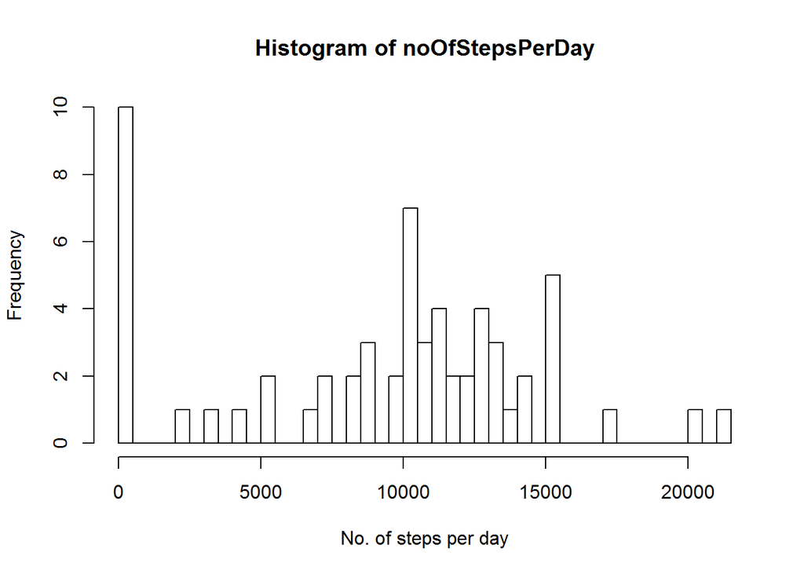

```r
mean(noOfStepsPerDay)
```

```
## [1] 9354.23
```

```r
median(noOfStepsPerDay)
```

```
## [1] 10395
```

```r
summary(noOfStepsPerDay)
```

```
##    Min. 1st Qu.  Median    Mean 3rd Qu.    Max.
##       0    6778   10400    9354   12810   21190
```

## What is the average daily activity pattern?

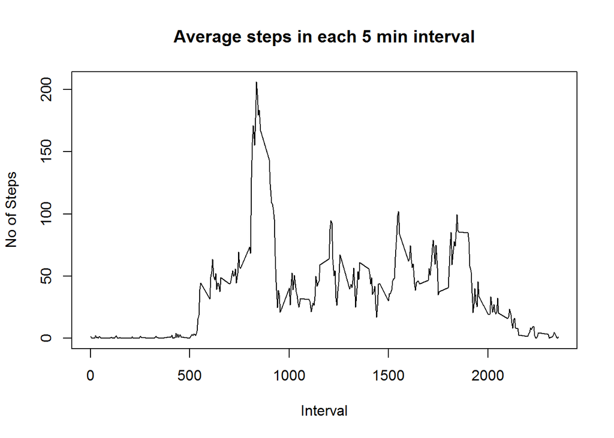

As the code below shows, the interval containing the maximum number of steps on average is 835 and the maximum average value is 206.1698 steps on average.

```r
summary(meanNoOfStepsPerInterval)
```

```
##    Min. 1st Qu.  Median    Mean 3rd Qu.    Max.
##   0.000   2.486  34.110  37.380  52.830 206.200
```

```r
meanNoOfStepsPerInterval[meanNoOfStepsPerInterval==max(meanNoOfStepsPerInterval)]
```

```
##      835
## 206.1698
```

## Imputing missing values

The methodology for imputting NA values in the data set has been set to be a mean of total values per interval. A new data set has been created by copying the raw data set to a new one. Then a column has been added containing mean values for each interval, which have then been rounded to an integer number. Wherever there were NAs in the “steps” column, the data from the column “meanPerInterval” has ben copied.

```r
activityFull <- activityRaw
summary(activityRaw$steps)
```

```
##    Min. 1st Qu.  Median    Mean 3rd Qu.    Max.    NA's
##    0.00    0.00    0.00   37.38   12.00  806.00    2304
```

```r
# Populate NA values with mean of steps for other days within the same interval
activityFull[, "meanPerInterval"] <- round(meanNoOfStepsPerInterval, digits = 0)

activityFull$steps = ifelse(is.na(activityFull$steps), activityFull$meanPerInterval, activityFull$steps)
```

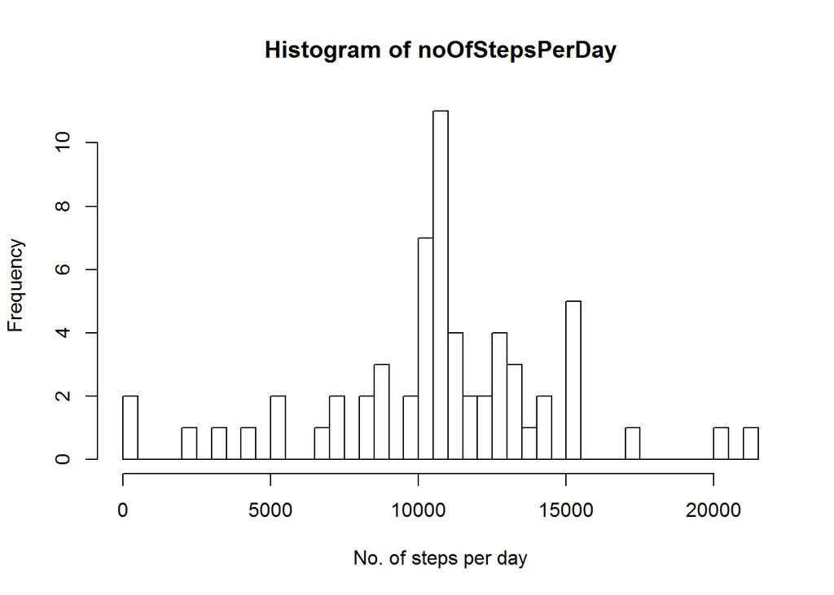

The mean and median values rose slightly comparing to the original measurements on the raw data

```r
mean(noOfStepsPerDay)
```

```
## [1] 10765.64
```

```r
median(noOfStepsPerDay)
```

```
## [1] 10762
```

```r
summary(noOfStepsPerDay)
```

```
##    Min. 1st Qu.  Median    Mean 3rd Qu.    Max.
##      41    9819   10760   10770   12810   21190
```

## Are there differences in activity patterns between weekdays and weekends?

First the data with imputed NA values is enhanced by adding additional columns specifying whether a particular day is a weekday or a weekend. Then “meanPerWeekdayIndicator” column is calculated and also added to the data frame.

```r
activityFull[, "weekdayIndicator"] <-
  ifelse(weekdays(activityFull$date) %in% c("Saturday", "Sunday"), "Weekend", "Weekday")
activityFull$weekdayIndicator <- factor(activityFull$weekdayIndicator)
activityFull[, "meanPerWeekdayIndicator"] <-
  ifelse(activityFull$weekdayIndicator == "Weekday",
         tapply(activityFull[activityFull$weekdayIndicator == "Weekday", ]$steps, activityFull[activityFull$weekdayIndicator == "Weekday", ]$interval, mean),
         tapply(activityFull[activityFull$weekdayIndicator == "Weekend", ]$steps, activityFull[activityFull$weekdayIndicator == "Weekend", ]$interval, mean))
```

The plot showing different interval patterns:

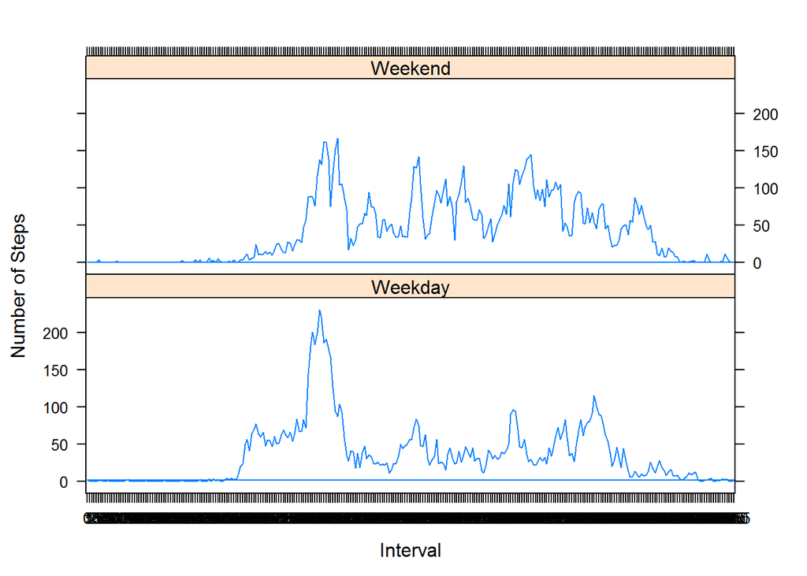